# Tablas de frecuencia

## TABLAS DE FRECUENCIA o matrices de confucion

primero abrimos el archivo college-per.cvs

```r
cp <- read.csv("college-perf.csv")
```

con la funcion “ordered” asignamos a los “FACTORES” Low, Medium y high niveles, es decir que Low vale menos que Medium y este vale menos que High

```r
cp$Perf <- ordered(cp$Perf,
                   levels = c("Low", "Medium", "High"))
cp$Pred <- ordered(cp$Pred,
                   levels = c("Low", "Medium", "High"))
```

TABLAS DE FRECUENCIA o Matrices de confucion usando la funcion “table”

```r
table <- table(cp$Perf, cp$Pred,
               dnn =  c("Actual", "Predecido"))
table
```

```
##         Predecido
## Actual    Low Medium High
##   Low    1150     84   98
##   Medium  166   1801  170
##   High     35     38  458
```

tambien podemos generar una tabla de frecuencia en porcentaje (en este caso todos los parametros son el 100%), usando la funcion “prop.table”

```r
prop.table(table)
```

```
##         Predecido
## Actual       Low  Medium    High
##   Low    0.28750 0.02100 0.02450
##   Medium 0.04150 0.45025 0.04250
##   High   0.00875 0.00950 0.11450
```

tambien podemos generar una tabla de de frecuencias en porcentaje tomando el 100% por fila o por columna de la siguiente manera:

```r
round(prop.table(table, 1)*100, 2)
```

```
##         Predecido
## Actual     Low Medium  High
##   Low    86.34   6.31  7.36
##   Medium  7.77  84.28  7.96
##   High    6.59   7.16 86.25
```

```r
#con 100% con las columnas
round(prop.table(table, 2)*100, 2)
```

```
##         Predecido
## Actual     Low Medium  High
##   Low    85.12   4.37 13.50
##   Medium 12.29  93.66 23.42
##   High    2.59   1.98 63.09
```

##visualizacion de tablas de frecuencia con DIAGRAMAS DE MOSAICO

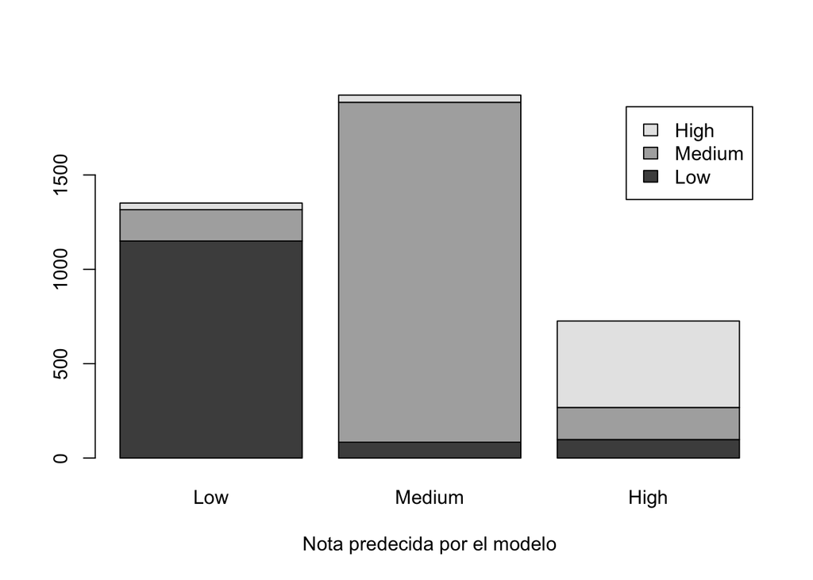

```r
barplot(table, legend = TRUE,
        xlab = "Nota predecida por el modelo")
```

Grafica tipo mosaico

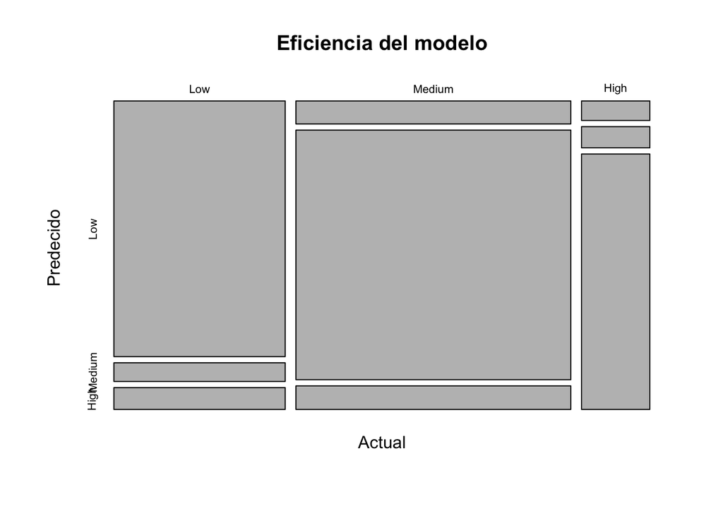

```r
mosaicplot(table, main = "Eficiencia del modelo")
```

para saber las estadisticas de las tablas de frecuencia usamos la funcion “summary”

```r
summary(table)
```

```
## Number of cases in table: 4000
## Number of factors: 2
## Test for independence of all factors:
##  Chisq = 4449, df = 4, p-value = 0
```

la cual nos da el numero total de casos u observaciones en la tabla (4000), numero de factores que se estan analizando (2), y un tambien hace un test de independencia para los dos factores que estamos analizando, es decir un TEST DE CHI CUADRADA (4449) con 4 grados de livertad y aqui un valor bajo de la P-value significa que las proporciones para las diferentes clases son singnificativamente diferente y que por lo tanto estan relacionadas es decir que no son independientes, en este caso “la eficiencia del modelo es buena”